# Demografi: opgaver 3

Johan Sebastian Ohlendorff

# Opgave 1

Diskuter den demografiske transition og dens faser ved at sammenligne aldersfordelinger (ældrekvote (Engelsk: dependency ratio), medianalder (Engelsk: median age)) i Danmark, USA, Indonesien og Nigeria på siden https://www.census.gov/data-tools/demo/idb/.

## Løsning

- Alderspyramide: https://www.census.gov/data-tools/demo/idb/#/pop?COUNTRY_YEAR=2024&menu=popViz&COUNTRY_YR_ANIM=2024&CCODE=DK,ID,NG,US&popPages=PYRAMID&ageGroup=1Y&POP_YEARS=2023&CCODE_SINGLE=**&measures=DEPND65_&TREND_RANGE=1950,2024&TREND_STEP=10&TREND_ADD_YRS=
- Medianalder: https://www.census.gov/data-tools/demo/idb/#/trends?COUNTRY_YEAR=2024&menu=trendsViz&COUNTRY_YR_ANIM=2024&CCODE=DK,ID,NG,US&popPages=BYAGE&ageGroup=1Y&POP_YEARS=2008&CCODE_SINGLE=**&measures=MEDAGE&TREND_RANGE=1950,2024&TREND_STEP=10&TREND_ADD_YRS=
- Ældrekvote: https://www.census.gov/data-tools/demo/idb/#/trends?COUNTRY_YEAR=2024&menu=trendsViz&COUNTRY_YR_ANIM=2024&CCODE=DK,ID,NG,US&popPages=BYAGE&ageGroup=1Y&POP_YEARS=2008&CCODE_SINGLE=**&measures=DEPND65_&TREND_RANGE=1950,2024&TREND_STEP=10&TREND_ADD_YRS=

## Løsning (del 2)

- Den demografiske transition beskriver en overgang fra et stadie med højt fertilitet og høj dødelighed til et stadie med lav dødelighed og lav fertilitet.
- Generelt ligner det at befolkningerne bliver ældre over tid, i de udviklede lande og Indonesien ift. ældrekvoten.
- Den samme tendens ses for medianalderen.
- Ift. alderspyramider i 2023: I Nigeria er befolkningen stadig meget ung. Danmark og USA ligner hinanden meget og har en ældre befolkning. Indonesien ligger et sted midt imellem.

# Opgave 2

Se på tidsudvikling af køns- og aldersfordelingen af folketal i Region Hovedstaden og Region Sjælland ved at sammenligne tal fra 2010 med tal fra 2020. Hvordan har befolkningspyramiden ændret sig og hvilke årsager kunne det have? Sammenlign bagefter køns- og aldersfordelingen af folketal mellem Region Hovedstaden og Region Sjælland i 2020. Hvad er mulige årsager for forskelle mellem regionerne?

## Løsning

```r
# R-koder der genererer alderspyramiden for 2 Regioner den 1. juli 2010 og 1. juli 2020
folk <- hent_data("FOLK1a","alder"=0:125,"køn"=1:2,tid=c("2010K3","2020K3"),Område = c("Region Hovedstaden","Region Sjælland"))
# Fjern tomme aldre
folk <- subset(folk,alder<106)
# Mænd skal vises på venstre siden, derfor bliver INDHOLD negativt
folk_m <- subset(folk,KØN=="Mænd") %>% mutate(INDHOLD=-INDHOLD)
# For kvinder på højre siden er INDHOLD  positivt
folk_k <- subset(folk,KØN=="Kvinder")
# Grafik
g <- ggplot(folk, aes(x = alder, y = INDHOLD, fill = KØN)) +
  geom_bar(data=folk_m, stat = "identity") +
  geom_bar(data=folk_k, stat = "identity") +
  coord_flip() + theme_economist() +
  ylab("Folketal N(t)")+xlab("Alder (år)") +
  theme(legend.title=element_blank())
g <- g+ggtitle("Alderspyramide Region Hovedstaden 1 juli 2020")
g <- g+theme(axis.title.y=element_text(margin=margin(t=0,r=20,b=0,l=0)))
g <- g+theme(axis.title.x=element_text(margin=margin(t=20,r=0,b=0,l=0)))
g + facet_grid(OMRÅDE~TID)
```

## Output

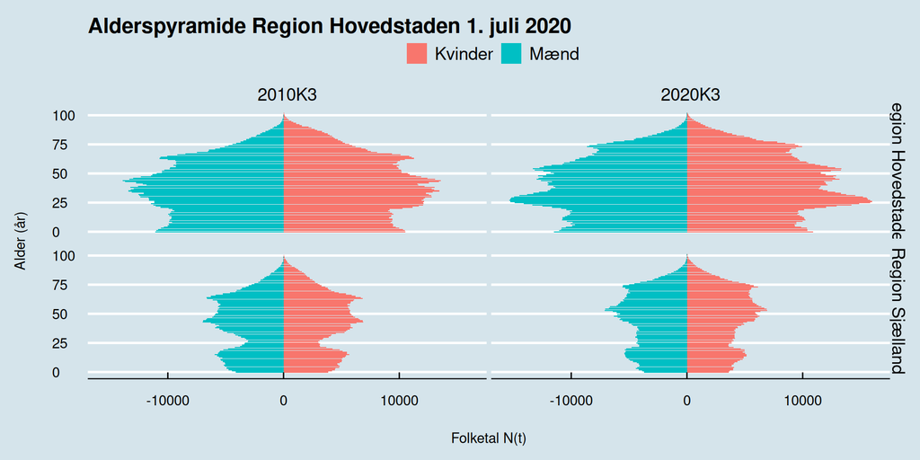

# Opgave 3

Beregn køns- og alderstandardiserede mortalitetsrater for Region Hovedstaden og Region Sjælland i henholdsvis 2010 og 2020 med hele den danske befolkning i 2020 som standardbefolkning. Brug direkte standardisering og 10 års aldersintervaller. Beregn og diskuter resultaterne med og uden alderstandardisering.

## Løsning

```r
dat <- hent_mortalitetsrate_data(breaks = c(seq(0,99,10),125),
                                 køn = c("Kvinder","Mænd"),
                                 område = c("Region Hovedstaden","Region Sjælland","Hele landet"),
                                 tid = c(2010,2020))
# aldersspecifikke mortalitetsrate
dat <- mutate(dat,M = 1000*Dod/R)
# summariske mortalitetsrate
sum_mrate <- dat %>% group_by(KØN,TID,OMRÅDE) %>% summarise(sum_mrate = 1000*sum(Dod)/sum(R),.groups = "keep")
# aldersfordeling standard befolkning
std <- hent_aldersfordeling(breaks = c(seq(0,99,10),125),
                            køn = c("Kvinder","Mænd"),
                            område = "Hele landet",
                            tid = c(2020))
# fjern risikotid R, OMRÅDE og TID
std <- mutate(std,R = NULL,OMRÅDE = NULL,TID = NULL)
# standardiserede mortalitetsrate
dat <- left_join(dat,std,by = c("aldersinterval","KØN"))
std_mrate <- dat %>% group_by(KØN,TID,OMRÅDE) %>% summarise(std_mrate = sum(M*V),.groups = "keep")
# join summariske og standardiserede rater
left_join(sum_mrate,std_mrate)
```

## Output

| Køn | Tid | Område | Summarisk mortalitetsrate (døde per 1000 personår) | Standardiseret mortalitetsrate (døde per 1000 personår) |
| --- | --- | --- | --- | --- |
| Kvinder | 2010 | Hele landet | 9,9 | 11,1 |
| Mænd | 2010 | Hele landet | 9,7 | 12,0 |
| Kvinder | 2020 | Hele landet | 9,1 | 9,1 |
| Mænd | 2020 | Hele landet | 9,7 | 9,7 |
| Kvinder | 2010 | Region Hovedstaden | 9,9 | 11,4 |
| Mænd | 2010 | Region Hovedstaden | 9,5 | 12,8 |
| Kvinder | 2020 | Region Hovedstaden | 8,3 | 9,2 |
| Mænd | 2020 | Region Hovedstaden | 8,6 | 10,0 |
| Kvinder | 2010 | Region Sjælland | 10,6 | 11,6 |
| Mænd | 2010 | Region Sjælland | 11,3 | 12,9 |
| Kvinder | 2020 | Region Sjælland | 10,5 | 9,6 |
| Mænd | 2020 | Region Sjælland | 11,7 | 10,5 |

## Kommentarer

- **Bemærk**: Den summariske og standardiserede mortalitetsrate er ens for mænd og kvinder i hele landet i 2020.
- Den standardiserede mortalitetsrate tager højde for forskellig aldersfordeling. Her har mænd altid højere mortalitetsrate end kvinder.

## Kommentarer (Del 2)

- Højere mortalitetsrater for standisering? Ældre befolkning i 2020.
- Tegn på lavere dødelighed i 2020 end i 2010 (når man kigger på den standardiserede rate).
- Standardiseret viser mindre forskelle for regionerne i 2010 end summarisk. Kan skyldes forskellig aldersfordeling - f.eks. flere unge i byerne.